# National Barber 1 (No Chemical) Practical Examination CIB

National-Interstate Council of State Boards of Cosmetology (NIC)

Effective Date: June 01, 2025 Revision Date: September 01, 2025

[figure not shown]

## CANDIDATE INFORMATION BULLETIN (CIB)

**EXAMINATION CONTENT AND IMPORTANT INSTRUCTIONS**

*Please visit your official examination provider website OR www.nictesting.org for the most current bulletin prior to testing.*

The National Barber 1 (No Chemical) Practical Examination is a licensure examination for Barber 1 (No Chemical), developed by the National-Interstate Council of State Boards of Cosmetology (NIC).

This bulletin contains IMPORTANT INFORMATION regarding National Barber 1 (No Chemical) Practical Examination content and administration for core services and additional sections and references.

*PLEASE REVIEW ALL INFORMATION CAREFULLY.*

For each NIC Practical Examination, there are multiple parts to every Candidate Information Bulletin (CIB):

- **Important Instructions and Examination Content Domain Sections** – This provides information and guidelines related to administration of the Practical examination and information about the scope of content covered in the core sections of the Practical examination.
- **Additional Services** – These provide information about additional sections offered by NIC for examination. Check with your State regulatory agency or examination administration vendor to determine which of these sections your State requires as part of their Practical examination.
- **References** – This provides a list of references used to develop and support the content covered in NIC examinations. References will be the same for Theory, Practical, Written Practical, and Additional Sections for each exam.

*BE CERTAIN TO REVIEW ALL PARTS OF THIS NIC EXAMINATION CIB CAREFULLY!*

## IMPORTANT INSTRUCTIONS

### General

- The NIC Practical examinations are designed to assess candidates’ ability to perform tasks expected to be performed while working as a licensed professional. The tasks a candidate will be asked to perform are those that frequently occur on-the-job and that are important to safe and proficient performance. Though the tasks are performed in an artificial testing session, efforts are made to make the tasks seem realistic and to closely mimic actual conditions. Candidates are expected to conduct themselves as if they were performing these tasks in actual scenarios.
- Do not leave the examination area without permission. Permission must be obtained to leave the examination area for any reason, including restroom usage or at the completion of the examination. *Picture ID is required for re-entry into the examination.*
- All examinations are administered in a testing environment.
- Candidates are evaluated at all times. Continue working until the entire section is complete or time has elapsed.

### Supplies

Candidates are required to bring a supply kit for their own use.

- It is the candidate’s responsibility to make certain they have a sufficient quantity of supplies that have been properly cleaned and disinfected and that implements are in proper working order.
- The kit will be used during the examination as dry storage and is considered part of the work area. The kit must be kept closed except when removing materials for a particular service.
- Candidates may remove items, supplies, etc., from the kit at any time, however *nothing* may be returned to the kit.
- EPA registered, disinfectant wipes that demonstrate bactericidal, fungicidal, and virucidal properties must be used. DISINFECTANT AND AEROSOL SPRAYS ARE NOT ALLOWED IN THE TESTING ENVIRONMENT.
- **All products must be labeled in English.** When an original manufacturer’s label is required, there can be NO handwritten or any other type of labeling. Original manufacturers’ labels must have English and may also include other languages. All non-manufacturer-created labels must be only in English. No labels indicating order of use when performing the service are allowed.
- Original manufacturer’s labels are *required* for all disinfectants and hand sanitizers.
- Simulated products are not allowed for disinfectants and hand sanitizers.
- Candidates are to perform all tasks, utilizing products and supplies, as they were taught. There is however, a section titled “Suggested Examination Supplies” provided for each section of the examination. Suggested Supplies can be found after the “Content Domains” section of this bulletin.

### Standardized Administration

Due to standardization of the NIC National Examinations, proctors and examiners are required to adhere to the following standards:

- All practical examinations are administered in English. The verbal instructions will be read twice for each section of the examination.
- With the exception of verbal instructions or an emergency situation, the proctors and/or examination administration personnel are not allowed to communicate with other testing candidates.
- Candidates requesting information during the examination will be told one of the following statements:
  - “Do the best you can with what you have available.”
  - “Do as you were taught.”
- If a candidate experiences an emergency situation, they may notify the proctor by raising their hand.
- Candidates will be given time to set up the universal (also known as general) supplies they will use throughout the examination.
  - Each section of the examination has a maximum time allowance, with the exception of those specified as untimed sections.
  - Once a candidate has completed all tasks in the section, they need to step back to indicate they have finished. In the event that all candidates complete a section before the time has elapsed, the examiners will proceed to the next section of the examination. When the timer goes off, all candidates must stop working and step back IMMEDIATELY.

#### Prohibited Items

- The following provides examples of materials and actions that are prohibited in the examination room during the examination administration:
  - Possession of cellular phones, watches (of any kind), pagers, tablets, computers, projectors, cameras, or any other electronic or recording devices, printed materials, or handwritten notes.
  - Purses, bags, coats, hats, and any other personal items not directly needed to complete the examination, are not allowed.
- Communicating to other candidates or any examiner.
- Exhibiting disruptive behavior. The above referenced items or actions are not an exhaustive list.

Failure to comply with any of these conditions or exhibiting ANY behavior that suggests an effort to cheat will result in immediate dismissal from the examination and the candidates’ actions reported to the proper authorities.

### Safety

- During all phases of the examination, candidates must follow all appropriate public protection and infection control procedures and maintain a safe work area.
- In the event of a blood exposure incident, candidates will be expected to follow proper blood exposure procedures.
- Failure to do so may result in dismissal from the examination.
- Be sure to contact the examination provider or State to obtain the most current version of, and any addenda to blood exposure procedures.
- If a candidate does not follow infection control procedures or allows the work area to become and remain unsafe, the result may be a failing score for the examination and could result in removal from the testing area.
- If a candidate experiences any unsafe conditions, they need to address it immediately.

### NIC Model or Mannequin Requirements

Please refer to your state specific guidelines for model and mannequin requirements. If your state requires that you use a mannequin head(s) :

- Candidates who are required to use a mannequin head(s) are responsible for coming prepared for the examination.
- Mannequin heads that are premarked for services or presectioned are not allowed for any part of the practical examination.
- Mannequin heads MUST be a full-size head, “minikin” or “junior” mannequin heads are NOT permitted.
- Mannequin heads must be approved by the examination state/vendor prior to admittance into examination.

### Special Attention

The following information is vital and specific to the NIC National Barber 1 (No Chemical) Practical Examination:

- Candidates will be evaluated on proper designation of materials that are disposed. Candidates are required to bring and use the following supplies for the appropriate disposal of materials:
  - Container labeled ‘To be disinfected’
  - Container labeled ‘Soiled linens’ -Container labeled ‘Trash’
- It is specified that there is more than one client represented for the purpose of this examination. A new client is introduced and must be prepared for during the course of the examination (see Barber 1 (No Chemical) Practical Examination Content Domains Sections).
- Candidates are expected to brace any time they are working around the eye and mouth areas.
- Candidates are not allowed to label products as single-use items.
- Use of single-use products may result in a failing score for the examination.
- A straight razor MUST be used.
- Check your state’s examination regulations for razor blade and live model and/or mannequin requirements.
- In accordance with manufacturer’s guidelines, gloves MUST be worn during disinfection procedures.

## BARBER 1 (NO CHEMICAL) PRACTICAL EXAMINATION CONTENT OUTLINE

### Core Domain Sections

The scope of the National Barber 1 (No Chemical) Practical Examination includes 5 (five) Core Domain Sections. The Core Domain Sections are based on the national job analysis.

1. Work Area and Client Preparation, and Set Up of Supplies
2. Haircutting
3. Work Area and New Client Preparation, and Set Up of Supplies
4. Shaving with a Straight Razor
5. Blood Exposure

### Domain Details

The following outlines the scope of content covered by the NIC National Barber 1 (No Chemical) Practical Examination.

**Proctor–Verbal Instructions: Read to all candidates:** *“Please go to your assigned station and do nothing until instructed by the Proctor.”*

#### 1. Work Area and Client Preparation, and Set Up of Supplies

**1. WORK AREA AND CLIENT PREPARATION, AND SET UP OF SUPPLIES (10 minutes) Proctor - Verbal Instructions: Read to all candidates:**

“*You will prepare your work area for your client.*

*You will set up the universal supplies you will use throughout the examination.*

*You will also set up the supplies for the Haircutting section of the examination.*

*You will prepare your client for services.*

*You will be expected to follow all client protection, safety and infection control procedures.*

*You will have 10 minutes to complete this section.*

*You will be informed when you have 5 minutes remaining.*

*Do not demonstrate any procedures until the verbal instructions are given and you are instructed to begin.*

*Step back to indicate you have finished.*

*(1) The instructions will be repeated.*

*(2) You may begin.*”

- **Candidates will be evaluated on the following tasks:**
- **1.1 Disinfects all work areas completely with product labeled in English as EPA-registered disinfectant that is bactericidal, virucidal, and fungicidal**
- **1.2 Sanitizes hands with product with manufacturer’s label in English**
- **1.3 Sets up supplies for Client 1**
- **1.4 Places items to be disinfected, soiled linens, and trash in correct containers throughout section**

**Proctor - Verbal Instructions: Read if all candidates have stepped back to indicate they have completed the section before the timing has elapsed:**

“*All candidates have indicated they have completed this section of the examination, we will now proceed.*”

**Proctor - Verbal Instructions:Read if the timer goes off before all candidates have stepped back:**

“*Please stop working.*”

#### 2. Haircutting

**2. HAIRCUTTING (40 minutes) Proctor - Verbal Instructions: Read to all candidates:**

“*You will prepare your client for services.*

*You will perform a scalp analysis.*

*You will perform a tapered Haircut with no blocked line at the nape.*

*You will demonstrate clipper cutting with and without guard or use a clipper with detachable blades.*

*You will demonstrate use of shear over comb.*

*You will demonstrate fingers and shear cutting.*

*You will be expected to complete and blend the haircut.*

*You will also be expected to shave both sides of the neck with a straight razor.*

*You will cut at least 1/2 inch of hair throughout the haircut.*

*You will be expected to complete and blend the haircut.*

*You will also be expected to shave both sides of the neck with a straight razor.*

*You will cut at least 1/2 inch of hair throughout the haircut.*

*Do not remove your hair clippings from your work area until you are instructed individually, by the examiner, to do so.*

*You will have 40 minutes to complete this section.*

*You will be informed when you have 20 minutes remaining.*

*Step back to indicate you have finished.*

*(1) The instructions will be repeated.*

*(2) You may begin.*”

- **Candidates will be evaluated on the following tasks:**
- **2.1Haircutting supplies are labeled in English**
- **2.2 Implements and supplies are visibly clean**
- **2.3 Performs scalp analysis**
- **2.4 Demonstrates safe use of clippers and comb without guard or detachable blade**
- **2.5 Demonstrates safe use of clippers with guard or detachable blade**
- **2.6 Demonstrates safe use of comb and shears**
- **2.7 Establishes outline around ears**
- **2.8 Shaves sides of the neck using straight razor to include reverse backhand stroke using all proper neck-shave procedures**

**Proctor - Verbal Instructions:Read if all candidates have stepped back to indicate they have completed the section before the timing has elapsed:**

“*All candidates have indicated they have completed this section of the examination.*

*Please do nothing until the next verbal instructions are given.*”

**Proctor - Verbal Instructions: Read if the timer goes off before all candidates have stepped back:**

“*Please stop working.*

*Please do nothing until the next verbal instructions are given.*”

**Examiner - Verbal Instructions: Read to each candidate individually:**

“*May I please use your comb to check the haircut?*”

- **2.9 Sideburns are uniform in length**
- **2.10 Haircut blended without weight line**
- **2.11 At least 1/2 inch of hair is cut throughout**

**Examiner - Verbal Instructions: Read to each candidate individually after the final appearance of the haircut has been examined:**

“*Please clean up your hair at this time.*

*You will breakdown your work area and dispose of supplies used in the previous sections of this examination.*

*Upon completion, please do nothing until the next verbal instructions are given.*”

- **2.12 Maintains drape throughout section**
- **2.13 Removes hair from work area**
- **2.14 Places items to be disinfected, soiled linens, and trash in correct containers throughout section**

**Proctor - Verbal Instructions:Read to candidates when all examiners have indicated they have completed their assessment :**

“*All examiners have indicated they are ready to proceed.*”

#### 3. Work Area and New Client Preparation, and Set Up of Supplies

“*You will prepare your work area for a NEW client.*

*You will set up the universal supplies you will use for the remainder of the examination.*

*You will prepare your client for a shave.*

*You will be expected to follow all client protection, safety and infection control procedures.*

*You will have 10 minutes to complete this section.*

*You will be informed when you have 5 minutes remaining.*

*Do not demonstrate any procedures until the verbal instructions are given and you are instructed to begin.*

*Step back to indicate you have finished.*

*(1) The instructions will be repeated.*

*(2) You may begin.*”

- **Candidates will be evaluated on the following tasks:**
- **3.1 Disinfects all work areas completely with product labeled in English as EPA-registered disinfectant that is bactericidal, virucidal, and fungicidal**
- **3.2 Sanitizes hands with product with manufacturer’s label in English**
- **3.3 Places items to be disinfected, soiled linens, and trash in correct containers throughout section**

**Proctor - Verbal Instructions: Read if all candidates have stepped back to indicate they have completed the section before the timing has elapsed:**

“*All candidates have indicated they have completed this section of the examination, we will now proceed.*”

**Proctor - Verbal Instructions:Read if the timer goes off before all candidates have stepped back:**

“*Please stop working.*”

#### 4. Shaving with a Straight Razor

**4. SHAVING WITH A STRAIGHT RAZOR (Variable Timing)Proctor - Verbal Instructions:Read to all candidates:**

“*You will prepare to perform shaving with a straight razor.*

*You will prepare the models face by lathering and steaming.*

*Do not remove the steam towel until instructed to do so by the examiner.*

*You will be expected to follow all client protection, safety and infection control procedures.*

*You will have 5 minutes to complete this section.*

*You will be informed when you have 2 minutes remaining.*

*Do not demonstrate any procedures until the verbal instructions are given and you are instructed to begin.*

*Step back to indicate you have finished.*

*(1) The instructions will be repeated.*

*(2) You may begin.*”

- **Candidates will be evaluated on the following tasks:**
- **4.1Sets up implements that are visibly clean**
- **4.2 Demonstrates proper draping and client preparation**
- **4.3Lathers beard and mustache area**
- **4.4Steam towel is applied**

**Proctor - Verbal Instructions:Read if all candidates have stepped back to indicate they have completed the section before the timing has elapsed:**

“*All candidates have indicated they have completed this section of the examination.*

*Please do nothing until the next verbal instructions are given.*”

**Proctor - Verbal Instructions: Read if the timer goes off before all candidates have stepped back:**

“*Please stop working.*

*Please do nothing until the next verbal instructions are given.*”

**Proctor - Verbal Instructions: Read to all candidates after all candidates have stepped back to indicate that they have completed their preparation:**

“*You will perform Shaving with a Straight Razor.*

*You will be expected to follow all client protection, safety and infection control procedures.*

*You will be instructed individually by the examiner when to remove the towel, re-lather, and begin the shave.*

*This is an untimed section.*

*Do not remove the steam towel or demonstrate any strokes until instructed individually by the examiner to do so.*

*(1) The instructions will be repeated.*”

**Examiner - Verbal Instructions: Read to each candidate individually:**

“*Please remove the steam towel, re-lather, and demonstrate shaving strokes 1, 3, 11; 2; 13 and 14.*”

- 4.5 Demonstrates freehand stroke in areas 1, 3, and 11 safely

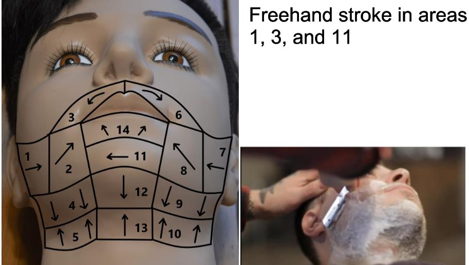

- 4.6 Demonstrates backhand stroke in area 2

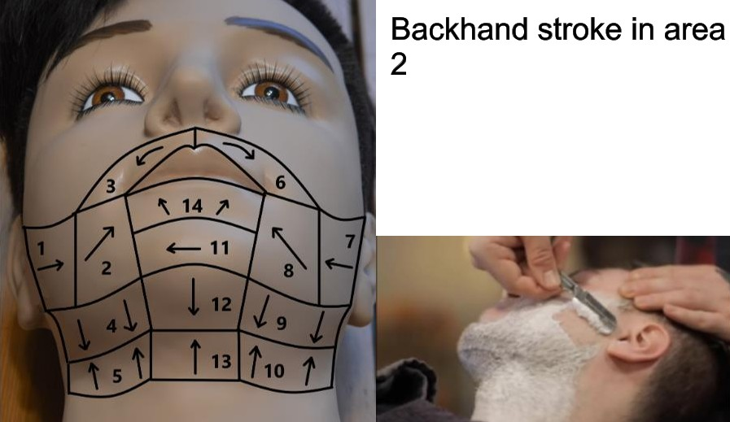

- **4.7 Demonstrates reverse freehand stroke in area 13 and 14 safely**

**Examiner - Verbal Instructions:Read to each candidate individually after the shaving with a straight razor has been examined:**

“*Please do nothing until the next verbal instructions are given.*”

**Proctor - Verbal Instructions: Read to all candidates after demonstrated strokes are evaluated:**

“*All examiners have indicated they are ready to proceed.*”

**Proctor - Verbal Instructions:Read to all candidates:**

“*Do not demonstrate any additional shaving strokes.*

*You will perform the finishing steps of the service.*

*You will be expected to follow all client protection, safety and infection control procedures.*

*You will have 5 minutes to complete this section.*

*You will be informed when you have 2 minutes remaining.*

*Step back to indicate you have finished.*

*(1)The instructions will be repeated.*

*(2)You may begin.*”

- **4.8 Completes the shaving service**
- **4.9 Maintains drape throughout section**
- **4.10 Places items to be disinfected, soiled linens, and trash in correct containers throughout section**

**Proctor - Verbal Instructions: Read if all candidates have stepped back to indicate they have completed the section before the timing has elapsed:**

“*All candidates have indicated they have completed this section of the examination, we will now proceed.*”

**Proctor - Verbal Instructions:Read if the timer goes off before all candidates have stepped back:**

“*Please stop working.*”

#### 5. Blood Exposure

**5. BLOOD EXPOSURE PROCEDURE (10 minutes)Proctor - Verbal Instructions: Read to all candidates:**

“*You will demonstrate the Blood Exposure Procedure.*

*You will imagine the following scenario: During a service, you have sustained a minor cut to your index finger.*

*The injury is such that you can continue with the service.*

*Your work area or client has not been contaminated.*

*You are expected to demonstrate the proper procedure for a blood exposure.*

*You will be expected to follow all client protection, safety and infection control procedures.*

*You will have 10 minutes to complete this section.*

*You will be informed when you have 5 minutes remaining.*

*Step back to indicate you have finished.*

*(1) The instructions will be repeated.*

*(2)You may begin.*”

- **Candidates will be evaluated on the following tasks:**
- **5.1Blood exposure supplies are labeled in English**
- **5.2Removes materials from first aid kit**
- **5.3Supplies and materials are visibly clean**
- **5.4 Cleans injured area with antiseptic**
- **5.5Covers with dressing that is absorbent and secured**
- **5.6Candidate wears glove or finger guard**
- **5.7Disposes of all contaminated supplies**

**Proctor - Verbal Instructions: Read if all candidates have stepped back to indicate they have completed the section before the timing has elapsed:**

“*All candidates have indicated they have completed this section of the examination, we will now proceed.*”

**Proctor - Verbal Instructions: Read if the timer goes off before all candidates have stepped back:**

“*Please stop working.*”

**CANDIDATE CLEANUP AND FINAL SUMMARY Proctor - Verbal Instructions: Read to all candidates at the conclusion of the examination:**

“*All examiners have indicated they have completed their assessment.*

*Make sure that all kit supplies and disposable materials are taken with you.*

*This concludes the National-Interstate Council of State Boards of Cosmetology, National Barber 1*

*- No Chemical Services Practical Examination.*

*Thank you for your participation.*”

## *SUGGESTED* EXAMINATION SUPPLIES

Suggested supply list:

- This is a list of suggested supplies for the practical examination.
- Candidates are responsible for bringing all needed materials, even if not included on this list.
- Tools must be in good working order.

Information related to labeling of supplies:

- ALL supplies must be labeled in English
- No other languages can be present unless an original manufacturer’s label is present in English
- All other created labels must be only English

Suggested Supplies

- Candidate Supply Kit to Serve as Dry Storage Area (Must be Closeable)
- Clippers (Must be Fully Charged, if Cordless)
- Cloth Towels
- Comb(s)
- Container Labeled “items to be Disinfected” (Recommended: Free-Standing Paper Bag with Plastic Liner)
- Container Labeled “soiled Linens” (Recommended: Free-Standing Paper Bag with Plastic Liner)
- Container Labeled “trash” (Recommended: Free-Standing Paper Bag with Plastic Liner)
- EPA-Registered Disinfectant Wipes with Manufacturer’s Label that Demonstrates Bactericidal, Fungicidal and Virucidal Properties Must be Used (Must be Actual Disinfectant Wipes)
- Gloves
- Guards/Detachable Blades
- Hair Brush(Es)
- Hair Clip(s) and/or Clamp(s)
- Hand Sanitizer and Manufacturer’s Label (Must be Actual Hand Sanitizer)
- Mannequin Head(s) and a Table Clamp or Tri-Pod (Pre-Markings or Pre-Sectioning on Mannequins is not Permitted)
- Neck Strip(s)
- Paper Towels
- Protective Capes (Child Size Capes may be Used for Mannequin)
- Shaving Cream (Non-Aerosol)
- Shears
- Spatula(s)
- Spray Bottle with Water
- Steam Towel
- Straight Razor(s)
- Toner, Talc, or Moisturizer

## NATIONAL-INTERSTATE COUNCIL OF STATE BOARDS OF COSMETOLOGY (NIC) REFERENCES

This list provides the references used to develop and support the content covered in the NIC examinations. References will be the same across exam types for each exam. Candidates are responsible for using these most updated versions of references, as these editions were used to reference exam material.

Reference Date: September 01, 2025

### Standard

*Milady Standard Barbering*

Copyrighted 2026

7th Edition

978-0-357-63937-5

Milady www.Milady.com

Info@Milady.com;

*Milady Standard Barbering*

Copyrighted 2017

6th Edition

9781305100558

Milady www.Milady.com

Info@Milady.com;

*Pivot Point Fundamentals: Barbering, (101B – 113B)*

Copyrighted ©2022 Pivot Point International, Inc.

1st Edition, 2nd printing

978-1-940593-95-1 (Coursebook set)

Pivot Point International, Inc. www.pivot-point.com

info@pivot-point.com; 847-886-0500, Ext. 7368

Copyright 2025 National-Interstate Council of State Boards of Cosmetology, Inc.